# Predição de Deputados Eleitos 2014

Dandara Sousa

26 de fevereiro de 2018

*Carregando bibliotecas necessárias*

*Carregando e arrumando os dados para a predição*

```r
data <- read.csv("train.csv")
test <- read.csv("test.csv")
submission <- read.csv("sample_submission.csv")

#facilitar análises futuras
data$isDeputado = ifelse(data$descricao_ocupacao == "DEPUTADO",1,0)


#criar partição
dataPartition <- createDataPartition(y = data$situacao_final, p=0.75, list=FALSE);
data.train <- data[dataPartition, ]
data.test <- data[-dataPartition, ]
```

**1. Há desbalanceamento das classes (isto é, uma classe tem muito mais instâncias que outra)? Em que proporção? Quais efeitos colaterais o desbalanceamento de classes pode causar no classificador?**

Como visto abaixo, a classe marjoritária é a de não eleitos. Sendo assim, há um desbalanceamento onde eleitos são apenas cerca de 10% dos dados. Isso pode causar para o modelo uma desigualdade na hora de aprender a classificar o resultado final. Para isso, mais abaixo usaremos um método para balancear as classes, criando instâncias das que estão baixas e eliminando das marjoritárias.

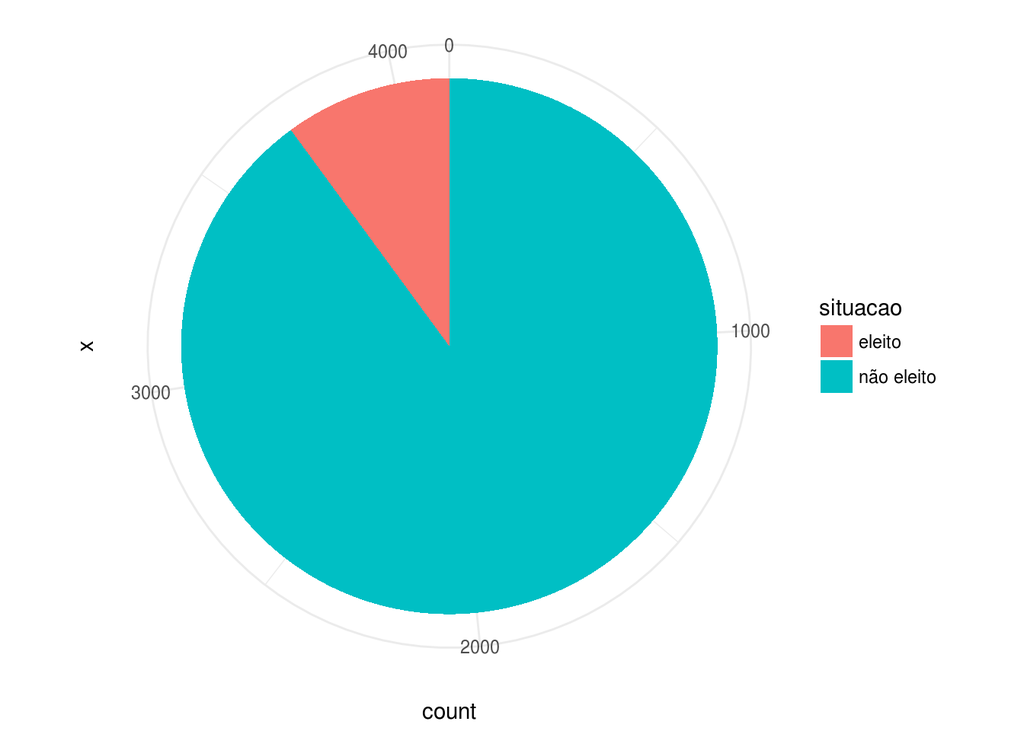

```r
n_eleitos <- data %>% filter(situacao_final == "eleito") %>% nrow()
n_neleitos <- data %>% filter(situacao_final == "nao_eleito") %>% nrow()

df = data.frame(situacao=c("eleito","não eleito"),count = c(n_eleitos, n_neleitos))

ggplot(df,aes(x="", y=count , fill= situacao)) +
  geom_bar(width = 1, stat = "identity") +
  coord_polar("y", start=0)
```

*analisando qual quais classes são realmente importantes para o modelo*

```r
formula = as.formula(situacao_final ~ partido + descricao_cor_raca + sexo + total_despesa + descricao_ocupacao + despesa_max_campanha)

model <- glm(formula = formula, data = data.train, family = "binomial")

summary(model)
```

```
##
## Call:
## glm(formula = formula, family = "binomial", data = data.train)
##
## Deviance Residuals:
##     Min       1Q   Median       3Q      Max
## -3.1938   0.0000   0.1376   0.2544   2.9738
##
## Coefficients:
##                                                                                            Estimate
## (Intercept)                                                                               2.033e+01
## partidoPCB                                                                                1.625e+01
## partidoPC do B                                                                           -2.479e-01
## partidoPCO                                                                                1.661e+01
## partidoPDT                                                                               -4.877e-01
## partidoPEN                                                                               -1.592e-01
## partidoPHS                                                                               -3.586e-01
## partidoPMDB                                                                              -3.142e-01
## partidoPMN                                                                                1.048e-01
## partidoPP                                                                                 4.924e-01
## partidoPPL                                                                                1.842e+01
## partidoPPS                                                                                4.485e-02
## partidoPR                                                                                -9.283e-01
## partidoPRB                                                                               -1.109e+00
## partidoPROS                                                                               6.373e-02
## partidoPRP                                                                               -4.010e-01
## partidoPRTB                                                                               1.670e+01
## partidoPSB                                                                               -9.323e-01
## partidoPSC                                                                               -7.956e-01
## partidoPSD                                                                               -7.105e-01
## partidoPSDB                                                                              -9.103e-01
## partidoPSDC                                                                               6.784e-01
## partidoPSL                                                                                8.404e-01
## partidoPSOL                                                                               2.655e-01
## partidoPSTU                                                                               1.681e+01
## partidoPT                                                                                -1.625e-01
## partidoPTB                                                                               -3.952e-01
## partidoPTC                                                                                1.647e+01
## partidoPT do B                                                                            2.541e+00
## partidoPTN                                                                               -1.017e+00
```

[output cut: 894 more lines]

```
## descricao_ocupacaoVEREADOR
## descricao_ocupacaoVETERINÁRIO
## descricao_ocupacaoVIGILANTE
## descricao_ocupacaoZOOTECNISTA
## despesa_max_campanha                                                                     ***
## ---
## Signif. codes:  0 '***' 0.001 '**' 0.01 '*' 0.05 '.' 0.1 ' ' 1
##
## (Dispersion parameter for binomial family taken to be 1)
##
##     Null deviance: 2024.71  on 3101  degrees of freedom
## Residual deviance:  846.61  on 2917  degrees of freedom
## AIC: 1216.6
##
## Number of Fisher Scoring iterations: 19
```

Vendo o modelo acima escolheremos as variáveis que possuem três ou duas * de acordo com o summary. Isso indica a importância da variável para a situação final do candidato.

```r
# os escolhidos são os que possuem *** ou ** dado o summary
data.train <- data.train %>%
  select(situacao_final, total_despesa, isDeputado, despesa_max_campanha)
data.test <- data.test %>%
  select(situacao_final, total_despesa, isDeputado, despesa_max_campanha)

#oversampling #undersampling

rose.train <- ROSE(situacao_final~., data = data.train)$data
table(rose.train$situacao_final)
```

```
##
## nao_eleito     eleito
##       1562       1540
```

```r
formula = as.formula(situacao_final ~.)
model.escolhidos <- glm(formula = formula, data = rose.train, family = "binomial")
summary(model.escolhidos)
```

```
##
## Call:
## glm(formula = formula, family = "binomial", data = rose.train)
##
## Deviance Residuals:
##     Min       1Q   Median       3Q      Max
## -3.7728  -0.6076  -0.4353   0.2814   3.2061
##
## Coefficients:
##                        Estimate Std. Error z value Pr(>|z|)
## (Intercept)          -1.699e+00  1.036e-01 -16.400   <2e-16 ***
## total_despesa         2.539e-06  1.191e-07  21.315   <2e-16 ***
## isDeputado            2.956e+00  1.814e-01  16.299   <2e-16 ***
## despesa_max_campanha  6.337e-09  2.195e-08   0.289    0.773
## ---
## Signif. codes:  0 '***' 0.001 '**' 0.01 '*' 0.05 '.' 0.1 ' ' 1
##
## (Dispersion parameter for binomial family taken to be 1)
##
##     Null deviance: 4300.1  on 3101  degrees of freedom
## Residual deviance: 2182.1  on 3098  degrees of freedom
## AIC: 2190.1
##
## Number of Fisher Scoring iterations: 7
```

Após utilizar o ROSE e observar o modelo apenas com as variáveis anteriormente escolhida percebe-se que a variável $despesa_max_cammpanha$ não influencia tanto. Por isso, vamos descondiserá-la daqui para frente.

**Treine: um modelo de regressão logística, uma árvore de decisão e um modelo de adaboost. Tune esses modelos usando validação cruzada e controle overfitting se necessário, considerando as particularidades de cada modelo.**

*treino*

```r
fitControl <- trainControl(method = "repeatedcv",
                           number = "10",
                           repeats = "5",
                           classProbs = TRUE
                           )
rose.train <- rose.train %>% select(situacao_final,total_despesa,isDeputado)
model.final <- glm(formula = formula, data = rose.train, family = "binomial")
summary(model.final)
```

```
##
## Call:
## glm(formula = formula, family = "binomial", data = rose.train)
##
## Deviance Residuals:
##     Min       1Q   Median       3Q      Max
## -3.7680  -0.6085  -0.4379   0.2820   3.2076
##
## Coefficients:
##                 Estimate Std. Error z value Pr(>|z|)
## (Intercept)   -1.676e+00  6.593e-02  -25.42   <2e-16 ***
## total_despesa  2.543e-06  1.184e-07   21.47   <2e-16 ***
## isDeputado     2.955e+00  1.813e-01   16.30   <2e-16 ***
## ---
## Signif. codes:  0 '***' 0.001 '**' 0.01 '*' 0.05 '.' 0.1 ' ' 1
##
## (Dispersion parameter for binomial family taken to be 1)
##
##     Null deviance: 4300.1  on 3101  degrees of freedom
## Residual deviance: 2182.2  on 3099  degrees of freedom
## AIC: 2188.2
##
## Number of Fisher Scoring iterations: 7
```

*arvore*

```r
arvore <- train(formula,
                 data=rose.train,
                 method = "rpart",
                 cp=0.001,  # parâmetro de complexidade
                 maxdepth=20)
arvore
```

```
## CART
##
## 3102 samples
##    2 predictors
##    2 classes: 'nao_eleito', 'eleito'
##
## No pre-processing
## Resampling: Bootstrapped (25 reps)
## Summary of sample sizes: 3102, 3102, 3102, 3102, 3102, 3102, ...
## Resampling results across tuning parameters:
##
##   cp          Accuracy   Kappa
##   0.03051948  0.9276022  0.8551147
##   0.09545455  0.9020774  0.8040185
##   0.75064935  0.6728729  0.3541739
##
## Accuracy was used to select the optimal model using the largest value.
## The final value used for the model was cp = 0.03051948.
```

```r
model.ada <- train(formula,
                   rose.train,
                   method = "adaboost"
                  )
model.ada
```

```
## AdaBoost Classification Trees
##
## 3102 samples
##    2 predictors
##    2 classes: 'nao_eleito', 'eleito'
##
## No pre-processing
## Resampling: Bootstrapped (25 reps)
## Summary of sample sizes: 3102, 3102, 3102, 3102, 3102, 3102, ...
## Resampling results across tuning parameters:
##
##   nIter  method         Accuracy   Kappa
##    50    Adaboost.M1    0.9415927  0.8831211
##    50    Real adaboost  0.9452905  0.8905181
##   100    Adaboost.M1    0.9417398  0.8834136
##   100    Real adaboost  0.9448322  0.8896044
##   150    Adaboost.M1    0.9421984  0.8843332
##   150    Real adaboost  0.9456446  0.8912275
##
## Accuracy was used to select the optimal model using the largest value.
## The final values used for the model were nIter = 150 and method =
##  Real adaboost.
```

**3.Reporte acurácia, precision, recall e f-measure no treino e validação. Como você avalia os resultados? Justifique sua resposta.**

Aqui, a acurácia será feita com o adaboost.

As métricas acima são definidas pelos seguintes termos:
$$Acurácia = (TP + TN)/(TP + TN + FP + FN)$$
Nos diz a proporção das observações que forma classificadas corretamente.
$$Precision = TP / (TP + FP)$$
Nos diz quantas das observações preditas como verdadeiras realmente são positivas.
$$Recall = TP / (TP + FN)$$
Nos diz quantas das observações positivas foram corretamente preditas.
Onde, TP são os verdadeiros positivos, TN os verdadeiros negativos, FP os falsos positivos e FN os falsos negativos.

```r
#predicao
data.test$prediction <- predict(model.ada,data.test)

TP <- data.test %>% filter(situacao_final == "eleito", prediction == "eleito") %>% nrow()
TN <- data.test %>% filter(situacao_final == "nao_eleito", prediction == "nao_eleito") %>% nrow()
FP <- data.test %>% filter(situacao_final == "nao_eleito", prediction == "eleito") %>% nrow()
FN <- data.test %>% filter(situacao_final == "eleito", prediction == "nao_eleito") %>% nrow()

accuracy <- (TP + TN)/(TP + TN + FP + FN)
precision <- TP / (TP + FP)
recall <- TP / (TP + FN)

f_measure <- 2 * (precision * recall) / (precision + recall)
```

```r
accuracy
```

```
## [1] 0.9351404
```

```r
precision
```

```
## [1] 0.6504065
```

```r
recall
```

```
## [1] 0.7692308
```

```r
f_measure
```

```
## [1] 0.7048458
```

O f-measure é calculado como a média harmônica da precisão e do recall. O valor mais próximo de 1 é mais satisfatório indicando que o modelo é um bom preditor.

```r
confusionMatrix(data.test$prediction,data.test$situacao_final)
```

```
## Confusion Matrix and Statistics
##
##             Reference
## Prediction   eleito nao_eleito
##   eleito         80         43
##   nao_eleito     24        886
##
##                Accuracy : 0.9351
##                  95% CI : (0.9184, 0.9494)
##     No Information Rate : 0.8993
##     P-Value [Acc > NIR] : 3.269e-05
##
##                   Kappa : 0.6687
##  Mcnemar's Test P-Value : 0.02787
##
##             Sensitivity : 0.76923
##             Specificity : 0.95371
##          Pos Pred Value : 0.65041
##          Neg Pred Value : 0.97363
##              Prevalence : 0.10068
##          Detection Rate : 0.07744
##    Detection Prevalence : 0.11907
##       Balanced Accuracy : 0.86147
##
##        'Positive' Class : eleito
##
```

**4.Interprete as saídas dos modelos. Quais atributos parecem ser mais importantes de acordo com cada modelo? Crie pelo menos um novo atributo que não está nos dados originais e estude o impacto desse atributo** Aproveitando o isDeputado já previamente criado vamos observar como ele impacta no modelo.

```r
data.train.dep <- data[dataPartition, ]
data.train.dep <- data.train.dep %>%
  select(situacao_final, total_despesa, isDeputado, despesa_max_campanha,descricao_ocupacao)

rose.train.dep <- ROSE(situacao_final~., data = data.train.dep)$data
rose.train.dep$isDeputado <- ifelse(rose.train.dep$descricao_ocupacao == "DEPUTADO", 1, 0)
rose.train.dep <- rose.train.dep %>% select(situacao_final, total_despesa, isDeputado, despesa_max_campanha)

model.dep <- glm(formula = situacao_final~.,rose.train.dep,family = binomial)
arvore.dep <- train(formula,
                 data=rose.train.dep,
                 method = "rpart",
                 cp=0.001,  # parâmetro de complexidade
                 maxdepth=20)
arvore.dep
```

```
## CART
##
## 3102 samples
##    3 predictors
##    2 classes: 'nao_eleito', 'eleito'
##
## No pre-processing
## Resampling: Bootstrapped (25 reps)
## Summary of sample sizes: 3102, 3102, 3102, 3102, 3102, 3102, ...
## Resampling results across tuning parameters:
##
##   cp          Accuracy   Kappa
##   0.03771131  0.9024547  0.8047253
##   0.07672302  0.8738168  0.7474418
##   0.71976593  0.7119826  0.4277387
##
## Accuracy was used to select the optimal model using the largest value.
## The final value used for the model was cp = 0.03771131.
```

```r
#model.ada.dep <- train(formula,
#                   rose.train.dep,
#                   method = "adaboost"
#                  )
#model.ada
```